# Quarto 기본사용법

Quarto 올바른 사용법!

Author

Affiliation

[이광춘](https://www.linkedin.com/in/kwangchunlee/)

[한국 R 사용자회](https://github.com/bit2r)

Published

August 13, 2022

**Warning**

2022년 6월 3일 Julia Müller가 R-Ladies Freiburg 에서 발표한 “Getting to know Quarto” 발표자료 기초하여 작성된 문서입니다. 자세한 사항은 [발표영상](https://www.youtube.com/watch?v=shVSmYna3GM&t=5s)과 [발표코드](https://github.com/rladies/meetup-presentations_freiburg/tree/master/2022-06-02_Quarto)를 참조 바랍니다.

# 1 사전 준비

## 1.1 데이터 선택

항상 모든 사람이들이 말하는데….

> 펭귄은 귀요미!

… 이제부터 펭귄 데이터로 즐거운 데이터 사이언스를 시작해봅시다.

**Note**

팔머펭귄(`palmerpenguins`) 데이터셋은 기계학습과 데이터 사이언스에 흔히 사용되는 붓꽃(`iris`) 데이터를 대체하기 위해 제작된 것입니다.

팔머펭귄 데이터셋에 대한 자세한 사항은 [Allison Horst’s Github page.](https://allisonhorst.github.io/palmerpenguins/) 웹사이트를 참조합니다.

**데이터 수집에 대해 궁금하신 분은 클릭하여 추가 학습하세요**

팔머펭귄 데이터는 Kristen Gorman 박사와 남국 팔머 관측소(Palmer Station, Antarctica LTER)에서 수집되어 공공에 이용가능하게 공개되었습니다.

{palmerpenguins} 패키지 (Horst et al., 2020)를 통해 R에서 손쉽게 이용가능하게 되었고 원데이터는 Gorman et al. (2014) 에서 최초 공개되었다.

## 1.2 데이터와 패키지 불러오기

먼저, 다음 작업을 순차적으로 수행한다:

1. **패키지** 적재하기(loading)
2. **데이터** 불러오기
3. 데이터가 *올바른 형식*인지 확인한다.

“올바른 형식”이란, 데이터가 정돈되어(tidy) 요약통계량, 시각화, 모형개발에 올바른 형태로 준비되어 있음을 의미함.

**다운로드하지 않고 데이터 사용하는 방법**

`palmerpenguins` 데이터 패키지에 동일한 데이터를 바로 이용할 수 있음.

```r
library(tidyverse)
penguins <- read_csv('https://raw.githubusercontent.com/rfordatascience/tidytuesday/master/data/2020/2020-07-28/penguins.csv') %>%
  drop_na()
head(penguins)
```

```
# A tibble: 6 × 8
  species island bill_length_mm bill_depth_mm flipper_length_… body_mass_g sex
  <chr>   <chr>           <dbl>         <dbl>            <dbl>       <dbl> <chr>
1 Adelie  Torge…           39.1          18.7              181        3750 male
2 Adelie  Torge…           39.5          17.4              186        3800 fema…
3 Adelie  Torge…           40.3          18                195        3250 fema…
4 Adelie  Torge…           36.7          19.3              193        3450 fema…
5 Adelie  Torge…           39.3          20.6              190        3650 male
6 Adelie  Torge…           38.9          17.8              181        3625 fema…
# … with 1 more variable: year <dbl>
```

결측값이 있어 제거함. 따라서 데이터는 관측점으로 총 333 행수를 갖게 됨 [^1].

## 1.3 요약 통계량

평균 부리 길이는 43.9927928 mm, 평균 부리 깊이는 17.1648649 mm.

테이터 수집 시기는 2007 년과 2009 년도 사이.

### 1.3.1 Base R과 Tidyverse 구문 비교

데이터프레임 특정 칼럼을 보는 코드를 Base R과 Tidyverse 구문으로 작성하면 차이를 확인할 수 있다.

**Base R**

```r
penguins$bill_length_mm
```

**Tidyverse**

```r
penguins %>% select(bill_length_mm)
```

# 2 시각화

시각화 그래프 제작을 위한 몇가지 아이디어:

- 펭귄 체중과 물갈퀴 길이
  - 전체 데이터를 대상으로
  - 혹은 각 펭귄 종별로 나눠서
  - 부가적으로 성별도 고려하여
- 물칼퀴 길이와 부리 길이
- 부리 길이(bill length)와 부리 깊이(bill depth)

## 2.1 펭귄 체중과 물갈퀴 길이

다음 그래프는 [{palmerpenguins} 패키지 소품문](https://allisonhorst.github.io/palmerpenguins/articles/examples.html)에 제시된 것은 간략하게 작성한 것임.

### 2.1.1 전체 데이터

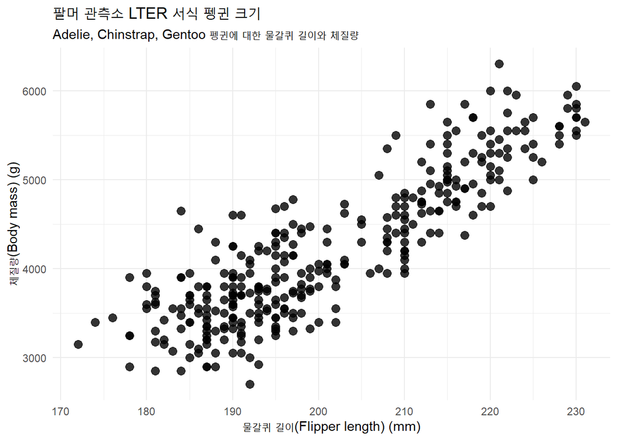

Figure 3: Penguin flipper length and body mass

```r
mass_flipper <- ggplot(data = penguins,
                       aes(x = flipper_length_mm,
                           y = body_mass_g)) +
  geom_point(size = 3,
             alpha = 0.8) +
  theme_minimal() +
  labs(title = "팔머 관측소 LTER 서식 펭귄 크기",
       subtitle = "Adelie, Chinstrap, Gentoo 펭귄에 대한 물갈퀴 길이와 체질량",
       x = "물갈퀴 길이(Flipper length) (mm)",
       y = "체질량(Body mass) (g)") +
  theme_minimal()

mass_flipper
```

### 2.1.2 펭귄 종별로 나눠서 시각화

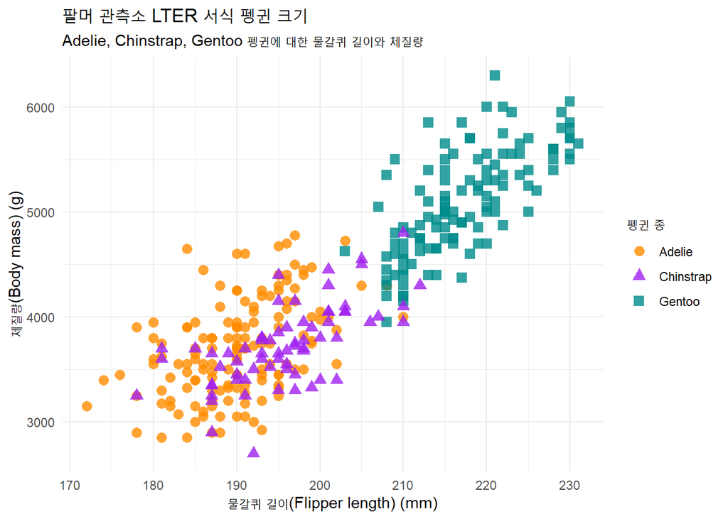

Figure 4: Penguin flipper length and body mass, separately by species

```r
mass_flipper_species <- ggplot(data = penguins,
                       aes(x = flipper_length_mm,
                           y = body_mass_g)) +
  geom_point(aes(color = species,
                 shape = species),
             size = 3,
             alpha = 0.8) +
  theme_minimal() +
  scale_color_manual(values = c("darkorange","purple","cyan4")) +
  labs(title = "팔머 관측소 LTER 서식 펭귄 크기",
       subtitle = "Adelie, Chinstrap, Gentoo 펭귄에 대한 물갈퀴 길이와 체질량",
       x = "물갈퀴 길이(Flipper length) (mm)",
       y = "체질량(Body mass) (g)",
       color = "펭귄 종",
       shape = "펭귄 종") +
  theme_minimal()

mass_flipper_species
```

Figure 3 그래프는 펭귄 종을 나누지 않았지만, Figure 4 그래프는 펭귄 종별로 나눠 시각화.

### 2.1.3 펭귄 종과 성별을 구분하여 시각화

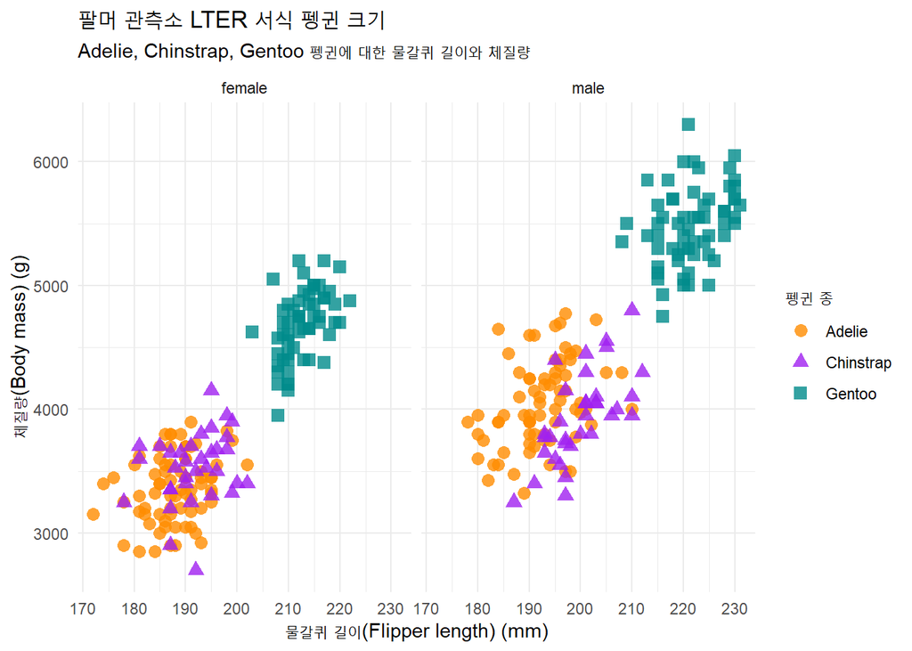

Figure 5: 펭귄 종과 성별로 나눠 펭귄 물갈퀴 길이와 체질량 시각화x

```r
mass_flipper_species +
  facet_wrap(~sex)
```

## References

Gorman, K. B., Williams, T. D., & Fraser, W. R. (2014). Ecological sexual dimorphism and environmental variability within a community of antarctic penguins (genus pygoscelis). *PloS One*, *9*(3), e90081. https://doi.org/10.1371/journal.pone.0090081

Horst, A. M., Hill, A. P., & Gorman, K. B. (2020). *Palmerpenguins: Palmer archipelago (antarctica) penguin data*. https://allisonhorst.github.io/palmerpenguins/

## Footnotes

[^1]: 결측값을 갖는 행은 무조건 제거함에 주의!